# 14_nuevo_reporte_operativo-FPC-BryanCastillo

**Reporte Táctico Operativo (RTO) semanas:**

09-09-2024 al 15-09-2024 y 16-09-2024 al 22-09-2024

El presente reporte muestra el despliegue territorial de los inspectores y monitores en sus procedimientos y requerimientos y puntos fijos en la comuna de San Ramón. Este documento constituye tablas cruzadas y mapas que orientan a los tomadores de decisiones a la planificación territorial de los recursos del área operativa de la Dirección de seguridad Pública San Ramón.

## Output: Procedimientos y requerimientos

### Output: Procedimientos y requerimientos: Mapas

El siguiente mapa muestra el total de casos asociados a procedimientos y requerimientos (procreq) en las dos últimas semanas, además de la diferencia de casos entre ellas.

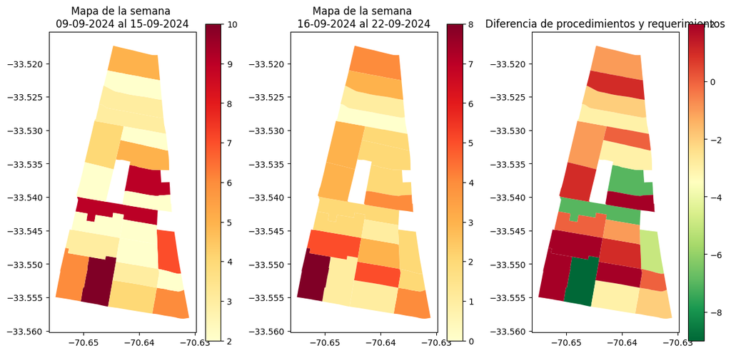

### Output: Puntos fijos: Mapas

El siguiente mapa muestra el total de casos asociados a puntos fijos (ptofijo) en las dos últimas semanas, además de la diferencia de casos entre ellas.

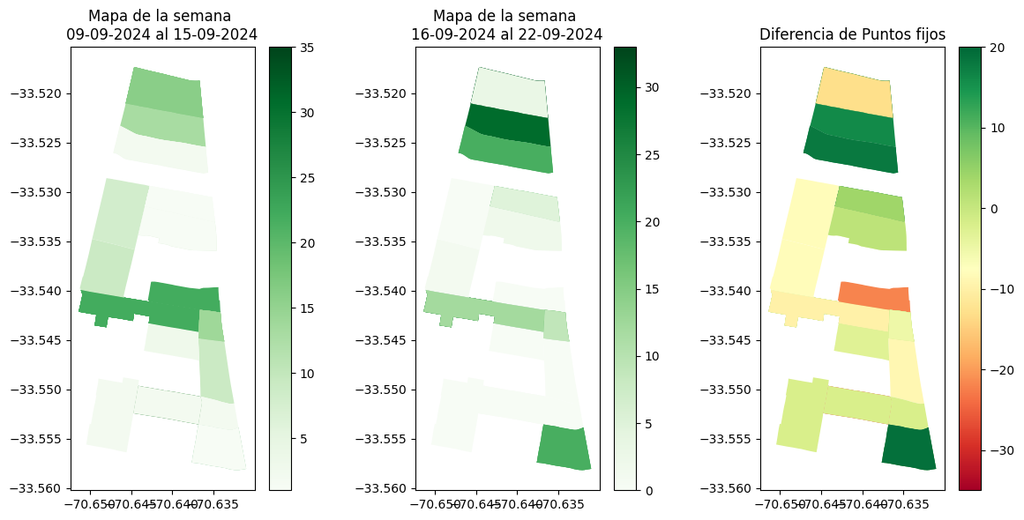

### Output: Procedimientos y requerimientos: Heatmap

La siguiente figura representa un heatmap o mapa de calor de una tabla cruzada de las unidades vecinales y la clasificación general del procedimiento y requerimiento de la última semana de análisis.

| CLASIFICACIÓN DEL REQUERIMIENTO UNIDAD VECINAL | DMCS | DROGAS | EMERGENCIAS | FISCALIZACION | INCIVILIDADES | S.MUNICIPALES | VIOLENCIA | VIOLENCIA INTRAFAMILIAR |
| --- | --- | --- | --- | --- | --- | --- | --- | --- |
| 1 | 2 | 0 | 0 | 1 | 0 | 1 | 0 | 0 |
| 2 | 1 | 0 | 0 | 1 | 0 | 0 | 0 | 0 |
| 3 | 0 | 0 | 1 | 0 | 0 | 0 | 0 | 0 |
| 4 | 1 | 0 | 1 | 1 | 2 | 0 | 0 | 0 |
| 5 | 0 | 0 | 2 | 0 | 1 | 0 | 0 | 0 |
| 6 | 0 | 0 | 0 | 1 | 0 | 0 | 0 | 0 |
| 7 | 0 | 0 | 0 | 0 | 1 | 0 | 0 | 0 |
| 8 | 5 | 0 | 2 | 0 | 0 | 0 | 1 | 0 |
| 9 | 2 | 0 | 1 | 0 | 2 | 0 | 0 | 0 |
| 10 | 0 | 0 | 0 | 1 | 1 | 0 | 0 | 0 |
| 11 | 1 | 0 | 1 | 0 | 0 | 0 | 0 | 0 |
| 12 | 1 | 0 | 0 | 0 | 1 | 2 | 0 | 0 |
| 13 | 2 | 0 | 0 | 0 | 0 | 0 | 0 | 0 |
| 15 | 1 | 0 | 1 | 0 | 0 | 0 | 0 | 0 |
| 16 | 1 | 0 | 1 | 0 | 0 | 0 | 1 | 0 |
| 17 | 1 | 1 | 1 | 0 | 0 | 0 | 0 | 0 |
| 18 | 0 | 0 | 1 | 0 | 1 | 0 | 0 | 0 |
| 19 | 1 | 0 | 0 | 0 | 1 | 0 | 0 | 0 |
| 21 | 0 | 0 | 0 | 0 | 0 | 0 | 0 | 1 |
| 22 | 1 | 1 | 0 | 0 | 1 | 0 | 0 | 0 |
| 23 | 0 | 1 | 1 | 1 | 1 | 0 | 0 | 0 |
| 24 | 0 | 0 | 0 | 0 | 0 | 1 | 1 | 0 |
| 25 | 0 | 0 | 1 | 0 | 0 | 0 | 0 | 0 |

La siguiente figura representa un heatmap o mapa de calor de una tabla cruzada de las unidades vecinales y la clasificación general del procedimiento y requerimiento de la penúltima semana de análisis.

| CLASIFICACIÓN DEL REQUERIMIENTO UNIDAD VECINAL | APOYO SOCIAL | DMCS | DROGAS | EMERGENCIAS | FISCALIZACION | INCIVILIDADES | MEJORAMIENTO VIAL | REPARACIÓN Y MANTENCIÓN DE SEÑALÉTICA | RETIRO DE RUCO | S.MUNICIPALES | VIOLENCIA |
| --- | --- | --- | --- | --- | --- | --- | --- | --- | --- | --- | --- |
| 1 | 0 | 0 | 1 | 0 | 0 | 1 | 0 | 0 | 1 | 3 | 0 |
| 2 | 0 | 0 | 0 | 0 | 2 | 0 | 3 | 0 | 0 | 2 | 0 |
| 3 | 0 | 0 | 0 | 1 | 1 | 1 | 0 | 0 | 0 | 1 | 0 |
| 4 | 0 | 0 | 0 | 0 | 0 | 1 | 0 | 0 | 0 | 1 | 1 |
| 5 | 0 | 1 | 0 | 0 | 0 | 0 | 0 | 0 | 0 | 1 | 0 |
| 6 | 0 | 0 | 0 | 0 | 0 | 0 | 0 | 0 | 0 | 2 | 0 |
| 7 | 0 | 1 | 0 | 2 | 2 | 0 | 0 | 0 | 0 | 3 | 2 |
| 8 | 0 | 1 | 0 | 1 | 2 | 2 | 0 | 0 | 0 | 0 | 0 |
| 9 | 0 | 2 | 0 | 0 | 0 | 1 | 0 | 0 | 0 | 0 | 0 |
| 10 | 0 | 0 | 0 | 0 | 0 | 0 | 0 | 0 | 0 | 1 | 1 |
| 11 | 0 | 2 | 0 | 2 | 2 | 0 | 0 | 1 | 0 | 2 | 0 |
| 12 | 0 | 0 | 1 | 0 | 1 | 0 | 0 | 0 | 0 | 0 | 0 |
| 13 | 0 | 0 | 0 | 0 | 3 | 2 | 0 | 0 | 1 | 3 | 0 |
| 16 | 0 | 0 | 0 | 0 | 0 | 0 | 0 | 0 | 0 | 1 | 1 |
| 17 | 0 | 0 | 0 | 1 | 1 | 1 | 0 | 0 | 0 | 1 | 0 |
| 18 | 0 | 0 | 0 | 2 | 3 | 0 | 0 | 0 | 0 | 0 | 0 |
| 19 | 0 | 0 | 0 | 0 | 1 | 0 | 0 | 0 | 1 | 0 | 0 |
| 20 | 0 | 1 | 0 | 0 | 1 | 0 | 0 | 0 | 0 | 1 | 0 |
| 21 | 0 | 0 | 0 | 1 | 2 | 0 | 0 | 0 | 0 | 0 | 0 |
| 22 | 0 | 0 | 0 | 1 | 0 | 1 | 0 | 0 | 0 | 0 | 0 |
| 23 | 1 | 3 | 0 | 0 | 0 | 0 | 0 | 0 | 0 | 1 | 0 |
| 24 | 0 | 1 | 0 | 0 | 0 | 0 | 0 | 0 | 1 | 0 | 0 |

La siguiente figura representa un heatmap o mapa de calor de una tabla cruzada de las diferencias de casos según el tipo de procedimientos y requerimientos por unidades vecinales de las dos últimas semanas.

| CLASIFICACIÓN DEL REQUERIMIENTO UNIDAD VECINAL | APOYO SOCIAL | DMCS | DROGAS | EMERGENCIAS | FISCALIZACION | INCIVILIDADES | MEJORAMIENTO VIAL | REPARACIÓN Y MANTENCIÓN DE SEÑALÉTICA | RETIRO DE RUCO | S.MUNICIPALES | VIOLENCIA | VIOLENCIA INTRAFAMILIAR |
| --- | --- | --- | --- | --- | --- | --- | --- | --- | --- | --- | --- | --- |
| 1 | 0.000000 | -2.000000 | 1.000000 | 0.000000 | -1.000000 | 1.000000 | 0.000000 | 0.000000 | 0.000000 | 2.000000 | 0.000000 | 0.000000 |
| 2 | 0.000000 | -1.000000 | 0.000000 | 0.000000 | 1.000000 | 0.000000 | 0.000000 | 0.000000 | 0.000000 | 2.000000 | 0.000000 | 0.000000 |
| 3 | 0.000000 | 0.000000 | 0.000000 | 0.000000 | 1.000000 | 1.000000 | 0.000000 | 0.000000 | 0.000000 | 1.000000 | 0.000000 | 0.000000 |
| 4 | 0.000000 | -1.000000 | 0.000000 | -1.000000 | -1.000000 | -1.000000 | 0.000000 | 0.000000 | 0.000000 | 1.000000 | 1.000000 | 0.000000 |
| 5 | 0.000000 | 1.000000 | 0.000000 | -2.000000 | 0.000000 | -1.000000 | 0.000000 | 0.000000 | 0.000000 | 1.000000 | 0.000000 | 0.000000 |
| 6 | 0.000000 | 0.000000 | 0.000000 | 0.000000 | -1.000000 | 0.000000 | 0.000000 | 0.000000 | 0.000000 | 2.000000 | 0.000000 | 0.000000 |
| 7 | 0.000000 | 1.000000 | 0.000000 | 2.000000 | 2.000000 | -1.000000 | 0.000000 | 0.000000 | 0.000000 | 3.000000 | 2.000000 | 0.000000 |
| 8 | 0.000000 | -4.000000 | 0.000000 | -1.000000 | 2.000000 | 2.000000 | 0.000000 | 0.000000 | 0.000000 | 0.000000 | -1.000000 | 0.000000 |
| 9 | 0.000000 | 0.000000 | 0.000000 | -1.000000 | 0.000000 | -1.000000 | 0.000000 | 0.000000 | 0.000000 | 0.000000 | 0.000000 | 0.000000 |
| 10 | 0.000000 | 0.000000 | 0.000000 | 0.000000 | -1.000000 | -1.000000 | 0.000000 | 0.000000 | 0.000000 | 1.000000 | 1.000000 | 0.000000 |
| 11 | 0.000000 | 1.000000 | 0.000000 | 1.000000 | 2.000000 | 0.000000 | 0.000000 | 0.000000 | 0.000000 | 2.000000 | 0.000000 | 0.000000 |
| 12 | 0.000000 | -1.000000 | 1.000000 | 0.000000 | 1.000000 | -1.000000 | 0.000000 | 0.000000 | 0.000000 | -2.000000 | 0.000000 | 0.000000 |
| 13 | 0.000000 | -2.000000 | 0.000000 | 0.000000 | 3.000000 | 2.000000 | 0.000000 | 0.000000 | 0.000000 | 3.000000 | 0.000000 | 0.000000 |
| 15 | 0.000000 | 0.000000 | 0.000000 | 0.000000 | 0.000000 | 0.000000 | 0.000000 | 0.000000 | 0.000000 | 0.000000 | 0.000000 | 0.000000 |
| 16 | 0.000000 | -1.000000 | 0.000000 | -1.000000 | 0.000000 | 0.000000 | 0.000000 | 0.000000 | 0.000000 | 1.000000 | 0.000000 | 0.000000 |
| 17 | 0.000000 | -1.000000 | -1.000000 | 0.000000 | 1.000000 | 1.000000 | 0.000000 | 0.000000 | 0.000000 | 1.000000 | 0.000000 | 0.000000 |
| 18 | 0.000000 | 0.000000 | 0.000000 | 1.000000 | 3.000000 | -1.000000 | 0.000000 | 0.000000 | 0.000000 | 0.000000 | 0.000000 | 0.000000 |
| 19 | 0.000000 | -1.000000 | 0.000000 | 0.000000 | 1.000000 | -1.000000 | 0.000000 | 0.000000 | 0.000000 | 0.000000 | 0.000000 | 0.000000 |
| 20 | 0.000000 | 0.000000 | 0.000000 | 0.000000 | 0.000000 | 0.000000 | 0.000000 | 0.000000 | 0.000000 | 0.000000 | 0.000000 | 0.000000 |
| 21 | 0.000000 | 0.000000 | 0.000000 | 1.000000 | 2.000000 | 0.000000 | 0.000000 | 0.000000 | 0.000000 | 0.000000 | 0.000000 | 0.000000 |
| 22 | 0.000000 | -1.000000 | -1.000000 | 1.000000 | 0.000000 | 0.000000 | 0.000000 | 0.000000 | 0.000000 | 0.000000 | 0.000000 | 0.000000 |
| 23 | 0.000000 | 3.000000 | -1.000000 | -1.000000 | -1.000000 | -1.000000 | 0.000000 | 0.000000 | 0.000000 | 1.000000 | 0.000000 | 0.000000 |
| 24 | 0.000000 | 1.000000 | 0.000000 | 0.000000 | 0.000000 | 0.000000 | 0.000000 | 0.000000 | 0.000000 | -1.000000 | -1.000000 | 0.000000 |
| 25 | 0.000000 | 0.000000 | 0.000000 | 0.000000 | 0.000000 | 0.000000 | 0.000000 | 0.000000 | 0.000000 | 0.000000 | 0.000000 | 0.000000 |

## Output: Procedimientos y requerimientos - Categorías relacionadas a casos violentos.

### Output: Heatmap de casos violentos

A continuación se despliega un mapa de calor de una tabla cruzada de la diferencia entre las dos últimas semanas de los procedimientos y requerimientos de casos violentos por unidad vecinal.

| CLASIFICACIÓN DEL REQUERIMIENTO UNIDAD VECINAL | DMCS | DROGAS | INCIVILIDADES | VIOLENCIA | VIOLENCIA INTRAFAMILIAR |
| --- | --- | --- | --- | --- | --- |
| 1 | -1 | 0 | 1 | 0 | 0 |
| 3 | 0 | 0 | 1 | 0 | 0 |
| 4 | 0 | 0 | 0 | 1 | 0 |
| 5 | 1 | 0 | -1 | 0 | 0 |
| 7 | 1 | 0 | 0 | 2 | 0 |
| 8 | -3 | 0 | 0 | -1 | 0 |
| 9 | 1 | 0 | 1 | 0 | 0 |
| 10 | 0 | 0 | 0 | 1 | 0 |
| 11 | 2 | 0 | 0 | 0 | 0 |
| 12 | 0 | 1 | 0 | 0 | 0 |
| 16 | 0 | 0 | 0 | 0 | 0 |
| 17 | 0 | -1 | 0 | 0 | 0 |
| 20 | 1 | 0 | 0 | 0 | 0 |
| 21 | 0 | 0 | 0 | 0 | -1 |
| 22 | -1 | -1 | -1 | 0 | 0 |
| 23 | 1 | 0 | -1 | 0 | 0 |
| 24 | 1 | 0 | 0 | -1 | 0 |

### Output: Mapa de casos violentos

A continuación se despliegan tres mapas de los procedimientos y requerimientos de casos violentos por unidad vecinal. Los dos primeros corresponden a las dos últimas semanas, y el el tercero a la diferencia de casos violentos por unidad vecinal.

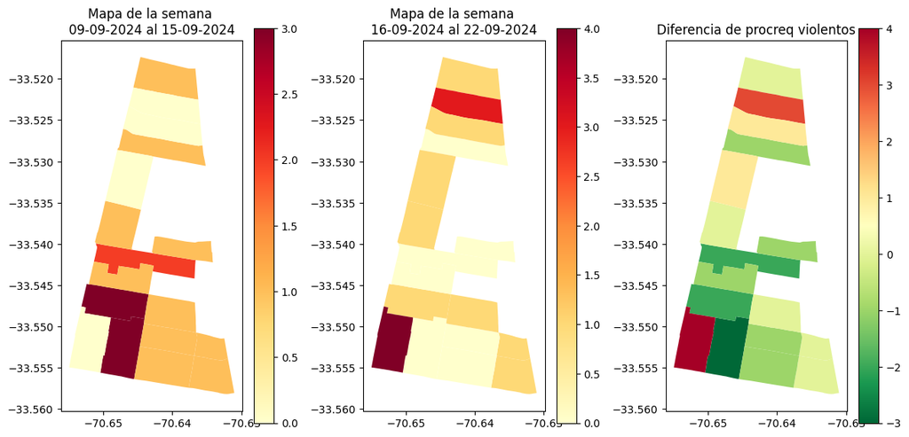

### Output: Mapa interactivo de casos violentos

A continuación se despliega un mapa interactivo de los procedimientos y requerimientos de casos violentos por unidad vecinal. Los casos están anonimizados por buffers y una pequeña traslación aleatoria. Puedes clickear el los buffer de los mapas para revisar detalles del caso.

Make this Notebook Trusted to load map: File -> Trust Notebook

[interactive chart not shown]